# exploratory_data_analysis_03

#### Handliing missing values in categorical features

- Ignore observations of missing values if we are dealing with large data sets and very few records have missing values. (unlikely approach)
- Ignore variable, if it is not significant.(unlikely approach)
- Treat missing data as just another category.
- **Replace with most frequent value.** (for now we will go with this apprach)
- Model based imputation: Build a model to predict missing values.

```python
def getNullPercentage(df, feature):
    null_count = len(df[df[feature].isnull()])
    percent_of_nulls = null_count*100/len(df)
    return null_count, percent_of_nulls

def isFeatureDropable(df, lst_featrues, threshold=75):
    sample_size = len(df)
    dict_drop_feat = dict()
    for feature in lst_featrues:
        null_count, percent_of_nulls = getNullPercentage(df, feature)
        print('Null count in {0} : {1}, Percent of Null: {2}'.format(feature, null_count, percent_of_nulls))
        if(percent_of_nulls > threshold):
            print('Drop --- {}'.format(feature))
            dict_drop_feat[feature] = True
        else:
            dict_drop_feat[feature] = False
    return dict_drop_feat

#print('Total Data size {0}'.format(sample_size))
#print('Missing data in Alley Feature {0}'.format(feature_missing_data_size))
#print('We could drop this feature as we have only {0}-{1} = {2} data points available'.format(sample_size, feature_missing_data_size, sample_size - feature_missing_data_size) )
```

```python
housing_train_set.dtypes.index
```

```
Index(['Id', 'MSSubClass', 'MSZoning', 'LotFrontage', 'LotArea', 'Street',
       'Alley', 'LotShape', 'LandContour', 'Utilities', 'LotConfig',
       'LandSlope', 'Neighborhood', 'Condition1', 'Condition2', 'BldgType',
       'HouseStyle', 'OverallQual', 'OverallCond', 'YearBuilt', 'YearRemodAdd',
       'RoofStyle', 'RoofMatl', 'Exterior1st', 'Exterior2nd', 'MasVnrType',
       'MasVnrArea', 'ExterQual', 'ExterCond', 'Foundation', 'BsmtQual',
       'BsmtCond', 'BsmtExposure', 'BsmtFinType1', 'BsmtFinSF1',
       'BsmtFinType2', 'BsmtFinSF2', 'BsmtUnfSF', 'TotalBsmtSF', 'Heating',
       'HeatingQC', 'CentralAir', 'Electrical', 'FstFlrSF', 'SecndFlrSF',
       'LowQualFinSF', 'GrLivArea', 'BsmtFullBath', 'BsmtHalfBath', 'FullBath',
       'HalfBath', 'BedroomAbvGr', 'KitchenAbvGr', 'KitchenQual',
       'TotRmsAbvGrd', 'Functional', 'Fireplaces', 'FireplaceQu', 'GarageType',
       'GarageYrBlt', 'GarageFinish', 'GarageCars', 'GarageArea', 'GarageQual',
       'GarageCond', 'PavedDrive', 'WoodDeckSF', 'OpenPorchSF',
       'EnclosedPorch', 'ThreeSsnPorch', 'ScreenPorch', 'PoolArea', 'PoolQC',
       'Fence', 'MiscFeature', 'MiscVal', 'MoSold', 'YrSold', 'SaleType',
       'SaleCondition', 'SalePrice'],
      dtype='object')
```

```python
def getCatFeaturesWithNulls(df):
    ser_dtypes = df.dtypes
    str_col_with_nulls = [x for x in ser_dtypes.index
                              if ser_dtypes[x] in ['object']
                                and len(df[df[x].notnull()]) < len(housing_data)]
    return str_col_with_nulls

def getCatFeatures(df):
    ser_dtypes = housing_data.dtypes
    cat_features = [x for x in ser_dtypes.index
                              if ser_dtypes[x] in ['object']]
    return cat_features
```

```python
#housing_data.drop('Alley', axis=1, inplace=True)
```

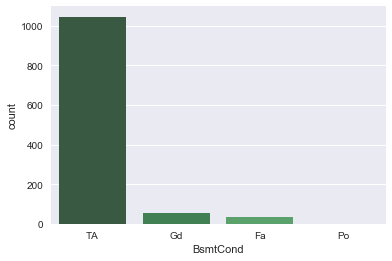

```python
sns.countplot(x="BsmtCond", data=housing_train_set, palette="Greens_d");
```

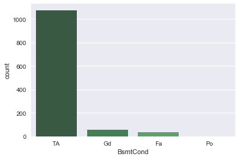

```python
housing_train_set.BsmtCond.fillna('TA', inplace=True)
sns.countplot(x="BsmtCond", data=housing_train_set, palette="Greens_d");
```

```python
housing_train_set['BsmtCond'].value_counts()
```

```
TA    1075
Gd      55
Fa      36
Po       1
Name: BsmtCond, dtype: int64
```

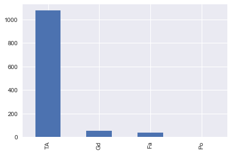

```python
housing_train_set['BsmtCond'].value_counts().plot(kind='bar')
```

```python
dict_drop_feat = isFeatureDropable(housing_train_set, getCatFeaturesWithNulls(housing_train_set))
```

```
Null count in MSZoning : 0, Percent of Null: 0.0
Null count in Street : 0, Percent of Null: 0.0
Null count in Alley : 1093, Percent of Null: 93.65895458440446
Drop --- Alley
Null count in LotShape : 0, Percent of Null: 0.0
Null count in LandContour : 0, Percent of Null: 0.0
Null count in Utilities : 0, Percent of Null: 0.0
Null count in LotConfig : 0, Percent of Null: 0.0
Null count in LandSlope : 0, Percent of Null: 0.0
Null count in Neighborhood : 0, Percent of Null: 0.0
Null count in Condition1 : 0, Percent of Null: 0.0
Null count in Condition2 : 0, Percent of Null: 0.0
Null count in BldgType : 0, Percent of Null: 0.0
Null count in HouseStyle : 0, Percent of Null: 0.0
Null count in RoofStyle : 0, Percent of Null: 0.0
Null count in RoofMatl : 0, Percent of Null: 0.0
Null count in Exterior1st : 0, Percent of Null: 0.0
Null count in Exterior2nd : 0, Percent of Null: 0.0
Null count in MasVnrType : 6, Percent of Null: 0.5141388174807198
Null count in ExterQual : 0, Percent of Null: 0.0
Null count in ExterCond : 0, Percent of Null: 0.0
Null count in Foundation : 0, Percent of Null: 0.0
Null count in BsmtQual : 30, Percent of Null: 2.570694087403599
Null count in BsmtCond : 0, Percent of Null: 0.0
Null count in BsmtExposure : 31, Percent of Null: 2.6563838903170525
Null count in BsmtFinType1 : 30, Percent of Null: 2.570694087403599
Null count in BsmtFinType2 : 31, Percent of Null: 2.6563838903170525
Null count in Heating : 0, Percent of Null: 0.0
Null count in HeatingQC : 0, Percent of Null: 0.0
Null count in CentralAir : 0, Percent of Null: 0.0
Null count in Electrical : 0, Percent of Null: 0.0
Null count in KitchenQual : 0, Percent of Null: 0.0
Null count in Functional : 0, Percent of Null: 0.0
Null count in FireplaceQu : 543, Percent of Null: 46.52956298200514
Null count in GarageType : 68, Percent of Null: 5.8269065981148245
Null count in GarageFinish : 68, Percent of Null: 5.8269065981148245
Null count in GarageQual : 68, Percent of Null: 5.8269065981148245
Null count in GarageCond : 68, Percent of Null: 5.8269065981148245
Null count in PavedDrive : 0, Percent of Null: 0.0
Null count in PoolQC : 1161, Percent of Null: 99.48586118251929
Drop --- PoolQC
Null count in Fence : 948, Percent of Null: 81.23393316195373
Drop --- Fence
Null count in MiscFeature : 1122, Percent of Null: 96.1439588688946
Drop --- MiscFeature
Null count in SaleType : 0, Percent of Null: 0.0
Null count in SaleCondition : 0, Percent of Null: 0.0
```

```python
# Delete features with more nulls.
print(housing_train_set.shape)
for col, flag in dict_drop_feat.items():
    if flag:
        housing_train_set.drop(col, axis=1, inplace=True)
print(housing_data.shape)
```

```
(1167, 81)
(1460, 81)
```

```python
dict_drop_feat = isFeatureDropable(housing_data, getCatFeaturesWithNulls(housing_train_set))
```

```
Null count in MSZoning : 0, Percent of Null: 0.0
Null count in Street : 0, Percent of Null: 0.0
Null count in LotShape : 0, Percent of Null: 0.0
Null count in LandContour : 0, Percent of Null: 0.0
Null count in Utilities : 0, Percent of Null: 0.0
Null count in LotConfig : 0, Percent of Null: 0.0
Null count in LandSlope : 0, Percent of Null: 0.0
Null count in Neighborhood : 0, Percent of Null: 0.0
Null count in Condition1 : 0, Percent of Null: 0.0
Null count in Condition2 : 0, Percent of Null: 0.0
Null count in BldgType : 0, Percent of Null: 0.0
Null count in HouseStyle : 0, Percent of Null: 0.0
Null count in RoofStyle : 0, Percent of Null: 0.0
Null count in RoofMatl : 0, Percent of Null: 0.0
Null count in Exterior1st : 0, Percent of Null: 0.0
Null count in Exterior2nd : 0, Percent of Null: 0.0
Null count in MasVnrType : 8, Percent of Null: 0.547945205479452
Null count in ExterQual : 0, Percent of Null: 0.0
Null count in ExterCond : 0, Percent of Null: 0.0
Null count in Foundation : 0, Percent of Null: 0.0
Null count in BsmtQual : 37, Percent of Null: 2.5342465753424657
Null count in BsmtCond : 37, Percent of Null: 2.5342465753424657
Null count in BsmtExposure : 38, Percent of Null: 2.6027397260273974
Null count in BsmtFinType1 : 37, Percent of Null: 2.5342465753424657
Null count in BsmtFinType2 : 38, Percent of Null: 2.6027397260273974
Null count in Heating : 0, Percent of Null: 0.0
Null count in HeatingQC : 0, Percent of Null: 0.0
Null count in CentralAir : 0, Percent of Null: 0.0
Null count in Electrical : 1, Percent of Null: 0.0684931506849315
Null count in KitchenQual : 0, Percent of Null: 0.0
Null count in Functional : 0, Percent of Null: 0.0
Null count in FireplaceQu : 690, Percent of Null: 47.26027397260274
Null count in GarageType : 81, Percent of Null: 5.5479452054794525
Null count in GarageFinish : 81, Percent of Null: 5.5479452054794525
Null count in GarageQual : 81, Percent of Null: 5.5479452054794525
Null count in GarageCond : 81, Percent of Null: 5.5479452054794525
Null count in PavedDrive : 0, Percent of Null: 0.0
Null count in SaleType : 0, Percent of Null: 0.0
Null count in SaleCondition : 0, Percent of Null: 0.0
```

**Check if there is any relation between above features and target variable (SalePrice)**. If the relation is strong enough, then keep the featrue and impute.

- Now let us see value counts of above features.

```python
lst_cat_feature = getCatFeaturesWithNulls(housing_train_set)
for feature in lst_cat_feature:
    null_count, percent_of_nulls = getNullPercentage(housing_train_set, feature)
    if(percent_of_nulls <= 75):
        print(housing_train_set[feature].value_counts())
```

```
RL         916
RM         176
FV          57
RH          11
C (all)      7
Name: MSZoning, dtype: int64
Pave    1162
Grvl       5
Name: Street, dtype: int64
Reg    723
IR1    397
IR2     38
IR3      9
Name: LotShape, dtype: int64
Lvl    1047
Bnk      52
HLS      38
Low      30
Name: LandContour, dtype: int64
AllPub    1166
NoSeWa       1
Name: Utilities, dtype: int64
Inside     832
Corner     211
CulDSac     86
FR2         36
FR3          2
Name: LotConfig, dtype: int64
Gtl    1109
Mod      46
Sev      12
Name: LandSlope, dtype: int64
NAmes      184
CollgCr    119
OldTown     94
Edwards     76
Somerst     75
Gilbert     66
Sawyer      59
NridgHt     57
```

[output cut: 222 more lines]

```
COD        32
ConLD       7
ConLw       5
ConLI       4
Oth         2
CWD         2
Con         2
Name: SaleType, dtype: int64
Normal     961
Partial    100
Abnorml     77
Family      15
Alloca      12
AdjLand      2
Name: SaleCondition, dtype: int64
```

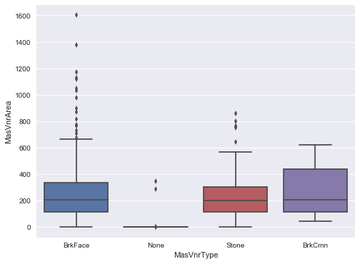

```python
var = 'MasVnrType'
data = pd.concat([housing_train_set['MasVnrArea'], housing_train_set[var]], axis=1)
f, ax = plt.subplots(figsize=(8, 6))
fig = sns.boxplot(x=var, y="MasVnrArea", data=data)
```

```python
housing_train_set['MasVnrType'].value_counts()
```

```
None       684
BrkFace    358
Stone      106
BrkCmn      13
Name: MasVnrType, dtype: int64
```

```python
housing_train_set.describe()
```

|  | Id | MSSubClass | LotFrontage | LotArea | OverallQual | OverallCond | YearBuilt | YearRemodAdd | MasVnrArea | BsmtFinSF1 | ... | WoodDeckSF | OpenPorchSF | EnclosedPorch | ThreeSsnPorch | ScreenPorch | PoolArea | MiscVal | MoSold | YrSold | SalePrice |
| --- | --- | --- | --- | --- | --- | --- | --- | --- | --- | --- | --- | --- | --- | --- | --- | --- | --- | --- | --- | --- | --- |
| count | 1167.000000 | 1167.000000 | 1167.000000 | 1167.000000 | 1167.000000 | 1167.000000 | 1167.000000 | 1167.000000 | 1167.000000 | 1167.000000 | ... | 1167.000000 | 1167.000000 | 1167.000000 | 1167.000000 | 1167.000000 | 1167.000000 | 1167.000000 | 1167.000000 | 1167.000000 | 1167.000000 |
| mean | 730.000857 | 57.283633 | 70.393908 | 10623.948586 | 6.127678 | 5.585261 | 1971.371894 | 1985.310197 | 106.246787 | 450.654670 | ... | 94.000857 | 48.946872 | 21.394173 | 3.428449 | 16.934019 | 2.958012 | 50.594687 | 6.366752 | 2007.830334 | 182825.841474 |
| std | 421.706438 | 42.408100 | 22.817782 | 9208.434346 | 1.384172 | 1.118711 | 30.333800 | 20.443910 | 185.375561 | 470.609181 | ... | 125.355019 | 69.336952 | 61.039794 | 30.175953 | 59.351266 | 41.666269 | 552.451967 | 2.700141 | 1.329958 | 81977.102916 |
| min | 1.000000 | 20.000000 | 21.000000 | 1477.000000 | 1.000000 | 1.000000 | 1875.000000 | 1950.000000 | 0.000000 | 0.000000 | ... | 0.000000 | 0.000000 | 0.000000 | 0.000000 | 0.000000 | 0.000000 | 0.000000 | 1.000000 | 2006.000000 | 34900.000000 |
| 25% | 365.500000 | 20.000000 | 60.000000 | 7597.500000 | 5.000000 | 5.000000 | 1954.000000 | 1968.000000 | 0.000000 | 0.000000 | ... | 0.000000 | 0.000000 | 0.000000 | 0.000000 | 0.000000 | 0.000000 | 0.000000 | 5.000000 | 2007.000000 | 131000.000000 |
| 50% | 730.000000 | 50.000000 | 70.393908 | 9571.000000 | 6.000000 | 5.000000 | 1973.000000 | 1994.000000 | 0.000000 | 387.000000 | ... | 0.000000 | 27.000000 | 0.000000 | 0.000000 | 0.000000 | 0.000000 | 0.000000 | 6.000000 | 2008.000000 | 164990.000000 |
| 75% | 1094.500000 | 70.000000 | 79.000000 | 11765.500000 | 7.000000 | 6.000000 | 2001.000000 | 2004.000000 | 170.000000 | 715.000000 | ... | 168.000000 | 70.000000 | 0.000000 | 0.000000 | 0.000000 | 0.000000 | 0.000000 | 8.000000 | 2009.000000 | 215000.000000 |
| max | 1460.000000 | 190.000000 | 313.000000 | 164660.000000 | 10.000000 | 9.000000 | 2009.000000 | 2010.000000 | 1600.000000 | 5644.000000 | ... | 857.000000 | 547.000000 | 552.000000 | 508.000000 | 480.000000 | 738.000000 | 15500.000000 | 12.000000 | 2010.000000 | 755000.000000 |

8 rows × 38 columns

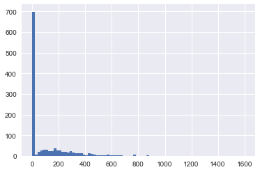

```python
# have a look at MasVnrArea as Q1 - 0, Q2 - 0, Q3 - 164 and max - 1600
#housing_data['MasVnrArea'].value_counts()
# Masonry veneer area in square feet, more than 75% of the houses have zero of this. Need to check if this featrue has
# any effect on SalePrice ?
housing_train_set.MasVnrArea.hist(bins=80)
```

#### Data Filtering

```
Shape of df_nz_vnr_area :  (479, 2)
Correlation between MasVnrArea - SalePrice
            MasVnrArea  SalePrice
MasVnrArea    1.000000   0.437375
SalePrice     0.437375   1.000000
```

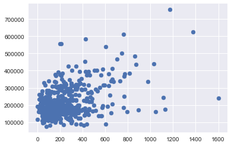

```python
df_nz_vnr_area = housing_train_set[housing_train_set.MasVnrArea != 0 & housing_train_set.MasVnrArea.notnull()][['MasVnrArea','SalePrice']]
print('Shape of df_nz_vnr_area : ', df_nz_vnr_area.shape)
print('Correlation between MasVnrArea - SalePrice ')
print(df_nz_vnr_area.corr())
plt.scatter(df_nz_vnr_area.MasVnrArea,df_nz_vnr_area.SalePrice)
```

```python
housing_train_set.drop('MasVnrArea', axis=1, inplace=True)
housing_train_set.drop('MasVnrType', axis=1, inplace=True)
```

```python
# I am going to drop rows with np.nan, I am doing this for training purposes. We have to handle all missing values in real-time
housing_train_set.dropna(axis=0, how='any', inplace=True)
```

```python
lst_missing_features = getMissingDataFeatures(housing_train_set)
lst_missing_features
```

```
[]
```

#### Aggregate the Data

To aggregate, we typically use the “group by” function, which involves the following steps

```
- Splitting the data into groups based on some criteria
- Applying a function to each group independently
- Combining the results into a data structure
```

```python
# Aggregate and analyze the trend of total sale price of different HouseStyles for YearBuilt
df_house_style = pd.pivot_table(housing_train_set, values='SalePrice', index=['YearBuilt'], columns=['HouseStyle'] )
df_house_style.head()
```

| HouseStyle YearBuilt | 1.5Fin | 1.5Unf | 1Story | 2.5Fin | 2.5Unf | 2Story | SFoyer | SLvl |
| --- | --- | --- | --- | --- | --- | --- | --- | --- |
| 1880 | NaN | NaN | NaN | 295000.0 | NaN | 265979.0 | NaN | NaN |
| 1882 | NaN | NaN | NaN | NaN | NaN | 168000.0 | NaN | NaN |
| 1892 | NaN | NaN | NaN | 475000.0 | NaN | NaN | NaN | NaN |
| 1893 | NaN | NaN | NaN | NaN | 325000.0 | NaN | NaN | NaN |
| 1900 | 160000.0 | NaN | NaN | NaN | NaN | 140000.0 | NaN | NaN |

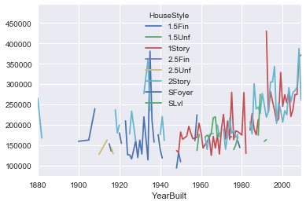

```python
df_house_style.plot()
```

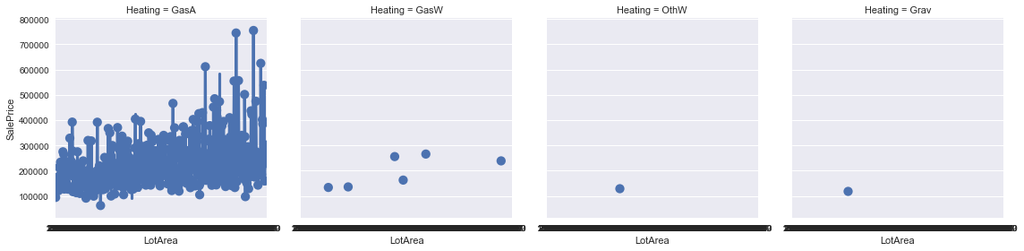

```python
# Get scatter plot group by col
sns.factorplot(data=housing_train_set, x="LotArea", y="SalePrice", col="Heating") # taking around 3 mins to generate
```

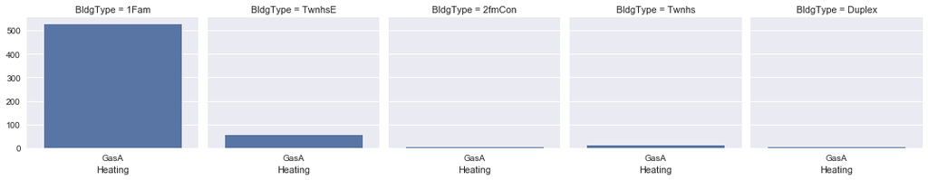

```python
# Get bar chart of one categorical variable by other categorical variable.
g = sns.FacetGrid(data=housing_train_set, col="BldgType")
g.map(sns.countplot, "Heating")
```

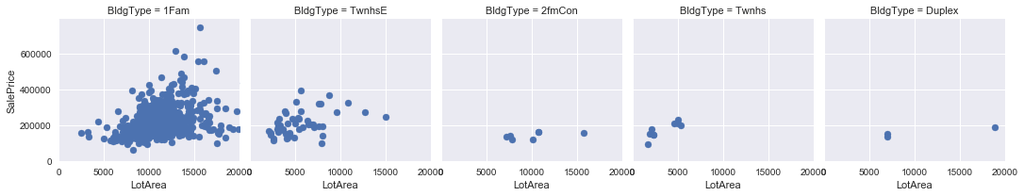

```python
# Get bar chart of one categorical variable by other categorical variable.
g = sns.FacetGrid(data=housing_train_set, col="BldgType")
g.map(plt.scatter, "LotArea", "SalePrice")
g.set(xlim=(0, 20000))
g.set(ylim=(0, None))
```

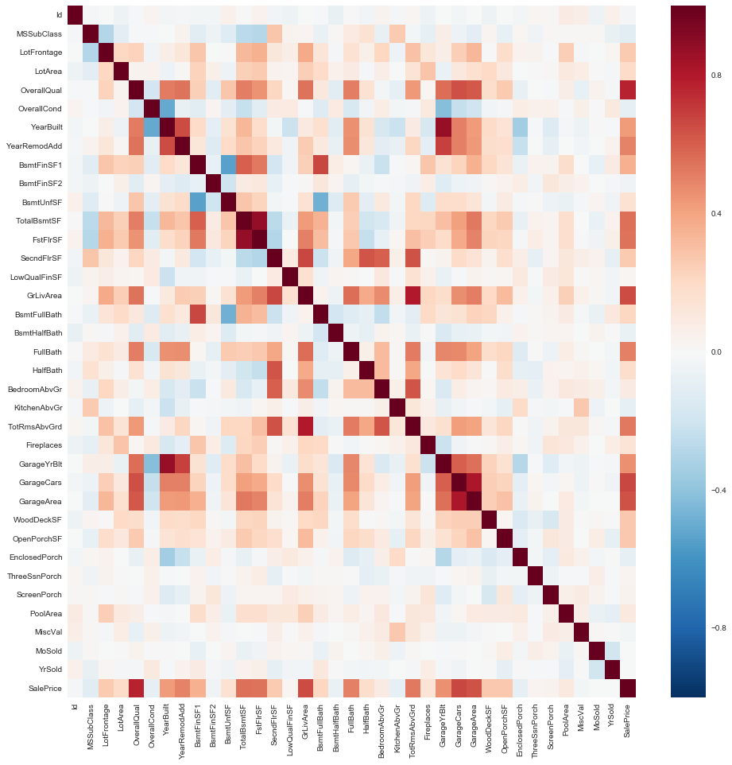

```python
plt.figure(figsize=(16, 16))
sns.heatmap(housing_train_set.corr())
```

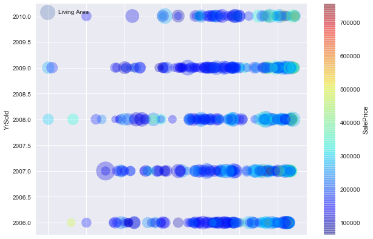

```python
housing_train_set.plot(kind="scatter", x="YearBuilt", y="YrSold",
    s=housing_data['GrLivArea']/5, label="Living Area",
    c="SalePrice", cmap=plt.get_cmap("jet"),
    colorbar=True, alpha=0.3, figsize=(10,7)
)
plt.legend()
plt.show()
```

```python
housing_train_set.YrSold.value_counts()
```

```
2006    144
2009    143
2007    141
2008    115
2010     66
Name: YrSold, dtype: int64
```

#### Quality of Data

```
* For this dataset we can check
1) is YearBuilt <= YrSold ?
2) is YearBuilt <= GarageYrBlt  ?
```

```python
print('Is YearBuilt <= YrSold : ', len(housing_train_set) == len(housing_train_set[housing_train_set['YearBuilt'] <= housing_train_set['YrSold']]))
```

```
Is YearBuilt <= YrSold :  True
```

```python
print('Is YearBuilt < GarageYrBlt : ', len(housing_train_set) == len(housing_train_set[housing_train_set['YearBuilt'] <= housing_train_set['GarageYrBlt']]))
```

```
Is YearBuilt < GarageYrBlt :  False
```

```python
# This records for which the Garage built before Building are not correct.
# This might have came because of the imputation method we chose.
housing_train_set[housing_train_set['GarageYrBlt'] < housing_train_set['YearBuilt']][['GarageYrBlt', 'YearBuilt']]
```

|  | GarageYrBlt | YearBuilt |
| --- | --- | --- |
| 75 | 1900.0 | 1910 |
| 259 | 1961.0 | 1967 |
| 480 | 2003.0 | 2005 |
| 882 | 1954.0 | 1959 |

```python
# Droping inconsistent data from the data frame.
housing_train_set.drop(housing_train_set[housing_train_set['GarageYrBlt'] < housing_train_set['YearBuilt']].index, inplace=True)
```

## Hypothesis Testing

> Question) Are old houses sold at less price?, Is it by chance ?

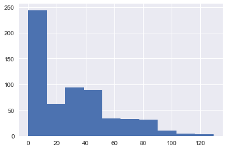

```python
housing_train_set['house_age'] = housing_train_set['YrSold'] - housing_train_set['YearBuilt']

housing_train_set['house_age'].hist()
```

```python
# Let us take the hourses older than 20 as old once.
house_age_below_20 = housing_train_set[housing_train_set.house_age <= 20]
house_age_above_20 = housing_train_set[housing_train_set.house_age > 20]
```

```python
sale_price_below_20 = house_age_below_20['SalePrice']
sale_price_above_20 = house_age_above_20['SalePrice']
print('Mean {0}, Std {1} Sale Price of house age <= 20'.format(sale_price_below_20.mean(), sale_price_below_20.std()))
print('Mean {0}, Std {1} Sale Price of house age > 20'.format(sale_price_above_20.mean(), sale_price_above_20.std()))
```

```
Mean 267092.0337837838, Std 95544.2335838447 Sale Price of house age <= 20
Mean 177352.43689320388, Std 54327.507282522456 Sale Price of house age > 20
```

```python
print("difference in means : ", sale_price_below_20.mean() - sale_price_above_20.mean())
```

```
difference in means :  89739.59689057991
```

**Null Hypothesis:** The mean sale prices of new building aren't significantly different than old ones.

```
- Perform **t-test** and determine the **p-value**.
```

```python
stats.ttest_ind(sale_price_below_20, sale_price_above_20, equal_var=True)
```

```
Ttest_indResult(statistic=14.27634397840254, pvalue=4.8056789308036893e-40)
```

The p-value is almost zero that said, we can reject Null Hypothesis. The older the house, less the price (threshold is 20 years)

## Assumption of t-test

```
* One assumption is that the data used came from a **normal distribution.**
* There's a Shapiro-Wilk test to test for normality.
```

**Shapior-Wilk Test :**

[output not shown]

**Note:** However, since the test is biased by sample size, the test may be statistically significant from a normal distribution in any large samples. Thus a Q–Q plot is required for verification in addition to the test.

```python
stats.shapiro(sale_price_below_20)
```

```
(0.8526212573051453, 3.8898606380158534e-16)
```

```python
stats.shapiro(sale_price_above_20)
```

```
(0.8875959515571594, 2.5949177905721342e-14)
```

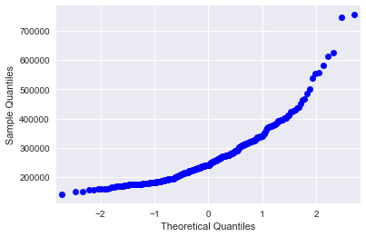

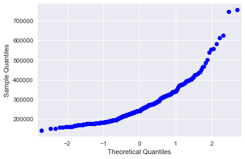

```python
qqplot(sale_price_below_20)
```

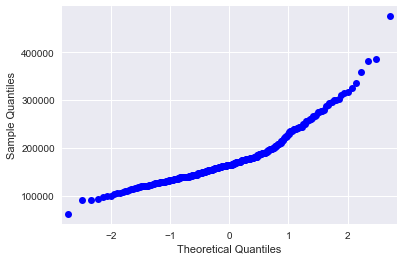

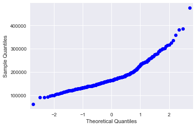

```python
qqplot(sale_price_above_20)
```

- Linear models rely upon a lot of assumptions. If assumptions are violated, the diagnostics obtained from the model cannot be relied.
- R-square vs adjusted R-squre : Biggest challenge is that adding any feature will increase the R-square. One way to counter this is to use adjusted R-squre.
- Take a step back and think - why do we need to report those numbers? We want some estimate of generalization. Cross-validation score provides a general framework for reporting generalization. And this will hold good across all models. And thus, multiple models can be compared. This is the machine learning approach and is widely used in practice.

### Try transform Skewed or non-normal distribution to normal by applying transformations.

```
- These transformations may or may not transorm data, but there is nothing wrong in trying.
```

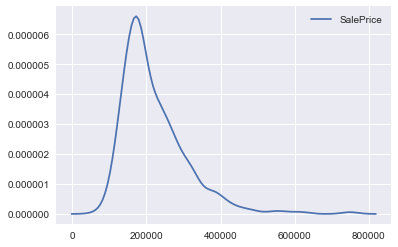

```python
sns.kdeplot(housing_train_set.SalePrice)
```

```python
stats.skew(housing_train_set.SalePrice)
```

```
1.851773732489688
```

```python
stats.skew(np.log(housing_train_set.SalePrice))
```

```
0.4834195268249695
```

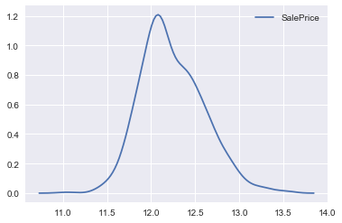

```python
sns.kdeplot(np.log(housing_train_set.SalePrice))
```

### Conclusion:

```
- Till now we have found few ways of exploring the data and gain insights.
- We have performed some data cleanup activity, before feeding the data to Machine Learning algorthm.
- We found some interesting correlations between featrues, especially with target variable.
- We found some tail heavy distributions and applied transformations to make the data normally distributed.
```